# Lesson1_Intro_to_R

Paul Lott

2024-05-13

The plan for the R/RStudio portion of the course is to provide an overview of RStudio, R Datatypes, Conditionals, Loops, Functions, and common R libraries. We unfortunately don’t have enough time to make you an expert at R. The goal is to get you to be proficient in RStudio on the HIVE Cluster.

# 1. Introduction to R

R is not only a programming language, but also a free software environment for statistical computing and graphics. In the past 20 years, R has been adopted in the fields of bioinformatics and data analysis as a fundamental tool.

R is an interpreted language (meaning it’s not compiled until you run it) - this makes it easy to share, download, and run script files from others. R provides a command-line interface and a Graphical User Interface. However, Third-party editors like **Rstudio** provide additional utilities that make it easier to program and use R.

If you want to download and run R/Rstudio on your own computer:

- [Download R](https://cran.r-project.org/)
- [Download RStudio Desktop](https://posit.co/download/rstudio-desktop)

## Allocating an Rstudio Instance on HIVE Ondemand

1. Login to HIVE OnDemand and select RStudio Server from the Interactive Apps

[figure not shown]

2. Provision the required amount of resources:

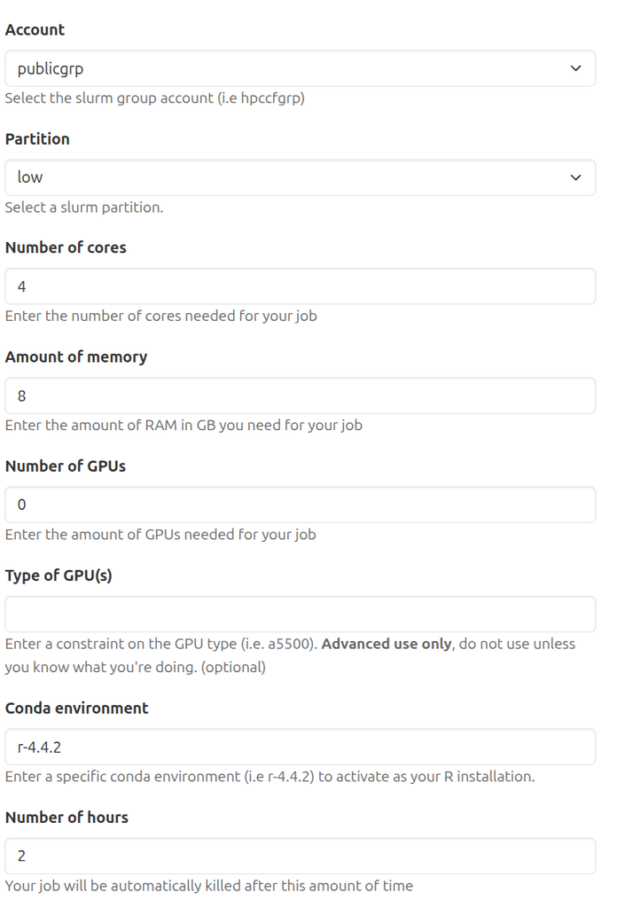

3. Click **“Launch”**
4. In “My Interactive Sessions”, click on **“Connect to RStudio Server”** after it has been setup

## Very Quick overview of the Original R

Let’s take a quick look at the R GUI/ R Command Line Console.

[figure not shown]

The R Console is where we can execute R commands. However, you’ll notice that it’s not a great place to keep track of Notes, Details, Code, or Plots.

## R Example Dataset

R has a lot of small example datasets available. [Datasets](https://stat.ethz.ch/R-manual/R-devel/library/datasets/html/00Index.html)

The Graphical console is very basic and limited.

The non-graphical console is even more basic and limited.

# Don’t Use R Gui/Console unless you need to.

For reproducibility, you need something better - where we can test, develop, and document our project code.

This is where **RStudio** really shines. OK - Let’s take a look at **RStudio** in Lesson 2.